# CourseraCapstone_pt3

Castelan Moreno, Emily

2022-11-25

#### Part 3 - Global Comparison

## THE DATASETS

```r
# Import global COVID-19 statistics aggregated by the Center for Systems Science and Engineering (CSSE) at Johns Hopkins University.
# Import global population estimates from the World Bank.

csse_global_deaths <- read_csv("https://raw.githubusercontent.com/CSSEGISandData/COVID-19/master/csse_covid_19_data/csse_covid_19_time_series/time_series_covid19_deaths_global.csv")
csse_global_cases <- read_csv("https://raw.githubusercontent.com/CSSEGISandData/COVID-19/master/csse_covid_19_data/csse_covid_19_time_series/time_series_covid19_confirmed_global.csv")
csse_us_deaths <- read_csv("https://raw.githubusercontent.com/CSSEGISandData/COVID-19/master/csse_covid_19_data/csse_covid_19_time_series/time_series_covid19_deaths_US.csv")
csse_us_cases <- read_csv("https://raw.githubusercontent.com/CSSEGISandData/COVID-19/master/csse_covid_19_data/csse_covid_19_time_series/time_series_covid19_confirmed_US.csv")

global_population_estimates <- read_csv("global_population_estimates.csv")
```

##### Question 1

Using the state you selected in Part 2 Question 2 compare the daily number of cases and deaths reported from the CSSE and NY Times. Create a Visualization to compare and contrast.

```r
## Load in CA state info from part 2
counties_combined <- rbind(us_counties_2020, us_counties_2021, us_counties_2022)

california_only <- counties_combined %>%
  filter(state == "California")

## the cases and deaths total for CA

california_Times <- california_only %>%
  group_by(date) %>%
  summarise(
    deaths_CA = sum(deaths),
    cases_CA = sum(cases)
  )

as_tibble(california_Times)
```

```
## # A tibble: 1,036 × 3
##    date       deaths_CA cases_CA
##    <date>         <dbl>    <dbl>
##  1 2020-01-25         0        1
##  2 2020-01-26         0        2
##  3 2020-01-27         0        2
##  4 2020-01-28         0        2
##  5 2020-01-29         0        2
##  6 2020-01-30         0        2
##  7 2020-01-31         0        3
##  8 2020-02-01         0        3
##  9 2020-02-02         0        6
## 10 2020-02-03         0        6
## # … with 1,026 more rows
```

```r
## 1) Now find the CA data reported by the CSSE cases and deaths
## try to rbind them together but they have different variables numbers
## also, they have the cases spread across variables instead of a date and cases
## columns so use pivot_longer() first to tidy then combine the data sets

csse_cases_tidy <- csse_us_cases %>%
  pivot_longer(
    cols = 12:1049,
    names_to = "date",
    values_to = "cases"
  )

as_tibble(csse_cases_tidy)
```

```
## # A tibble: 3,468,996 × 14
##         UID iso2  iso3  code3  FIPS Admin2  Provin…¹ Count…²   Lat Long_ Combi…³
##       <dbl> <chr> <chr> <dbl> <dbl> <chr>   <chr>    <chr>   <dbl> <dbl> <chr>
##  1 84001001 US    USA     840  1001 Autauga Alabama  US       32.5 -86.6 Autaug…
##  2 84001001 US    USA     840  1001 Autauga Alabama  US       32.5 -86.6 Autaug…
##  3 84001001 US    USA     840  1001 Autauga Alabama  US       32.5 -86.6 Autaug…
##  4 84001001 US    USA     840  1001 Autauga Alabama  US       32.5 -86.6 Autaug…
##  5 84001001 US    USA     840  1001 Autauga Alabama  US       32.5 -86.6 Autaug…
##  6 84001001 US    USA     840  1001 Autauga Alabama  US       32.5 -86.6 Autaug…
##  7 84001001 US    USA     840  1001 Autauga Alabama  US       32.5 -86.6 Autaug…
##  8 84001001 US    USA     840  1001 Autauga Alabama  US       32.5 -86.6 Autaug…
##  9 84001001 US    USA     840  1001 Autauga Alabama  US       32.5 -86.6 Autaug…
## 10 84001001 US    USA     840  1001 Autauga Alabama  US       32.5 -86.6 Autaug…
## # … with 3,468,986 more rows, 3 more variables: `11/25/22` <dbl>, date <chr>,
## #   cases <dbl>, and abbreviated variable names ¹Province_State,
## #   ²Country_Region, ³Combined_Key
```

```r
csse_deaths_tidy <- csse_us_deaths %>%
  pivot_longer(
    cols = 12:1049,
    names_to = "date",
    values_to = "deaths"
  )
csse_deaths_tidy <- csse_deaths_tidy[-c(12)]

as_tibble(csse_deaths_tidy)
```

```
## # A tibble: 3,468,996 × 14
##         UID iso2  iso3  code3  FIPS Admin2  Provin…¹ Count…²   Lat Long_ Combi…³
##       <dbl> <chr> <chr> <dbl> <dbl> <chr>   <chr>    <chr>   <dbl> <dbl> <chr>
##  1 84001001 US    USA     840  1001 Autauga Alabama  US       32.5 -86.6 Autaug…
##  2 84001001 US    USA     840  1001 Autauga Alabama  US       32.5 -86.6 Autaug…
##  3 84001001 US    USA     840  1001 Autauga Alabama  US       32.5 -86.6 Autaug…
##  4 84001001 US    USA     840  1001 Autauga Alabama  US       32.5 -86.6 Autaug…
##  5 84001001 US    USA     840  1001 Autauga Alabama  US       32.5 -86.6 Autaug…
##  6 84001001 US    USA     840  1001 Autauga Alabama  US       32.5 -86.6 Autaug…
##  7 84001001 US    USA     840  1001 Autauga Alabama  US       32.5 -86.6 Autaug…
##  8 84001001 US    USA     840  1001 Autauga Alabama  US       32.5 -86.6 Autaug…
##  9 84001001 US    USA     840  1001 Autauga Alabama  US       32.5 -86.6 Autaug…
## 10 84001001 US    USA     840  1001 Autauga Alabama  US       32.5 -86.6 Autaug…
## # … with 3,468,986 more rows, 3 more variables: `11/25/22` <dbl>, date <chr>,
## #   deaths <dbl>, and abbreviated variable names ¹Province_State,
## #   ²Country_Region, ³Combined_Key
```

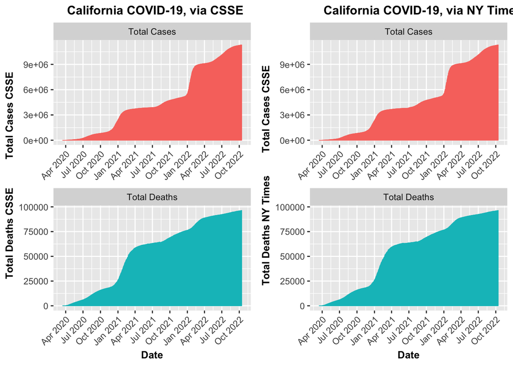

```r
## 2) now combine the two using a left join
csse_combined <- right_join(
  csse_cases_tidy,
  csse_deaths_tidy,
  by = c("UID", "iso2", "iso3", "code3", "FIPS", "Admin2", "Province_State",
         "Country_Region", "Lat", "Long_", "Combined_Key", "date")
)

## 3) the date is not actually a date class, which means it won't work with
## functions that we need, use as.date() and specify the format

csse_combined$date <- as.Date(csse_combined$date, "%m/%d/%y")

## 4) now filter for California info, the other data set starts on 2020-01-25
csse_CA <- csse_combined %>%
  filter(Province_State == "California") %>%
  group_by(date) %>%
  summarise(
    cases = sum(cases),
    deaths = sum(deaths)
  ) %>%
  filter(date >= "2020-01-25") %>%
  arrange(date) %>%
  rename(
    csse_cases = 2,
    csse_deaths = 3
  )

## 5) now create a visualization
## start with CA dataset from NY Times

CA_plot_data_Times <- california_Times %>%
  pivot_longer(
    cols = 2:3,
    names_to = "type",
    values_to = "number_reported"
  ) %>%
  filter(
    date != "2022-11-24"
  )

CA_plot_data_CSSE <- csse_CA %>%
  pivot_longer(
    cols = 2:3,
    names_to = "type",
    values_to = "number_reported"
  )

## 6) variables to label the plots for NY TIMES

variable_names <- list(
  "cases_CA" = "Total Cases" ,
  "deaths_CA" = "Total Deaths"
)

variable_labeller <- function(variable, value){
  return(variable_names[value])
}

## 6b) variables to label the plots for CSSE
variable_names2 <- list(
  "csse_cases" = "Total Cases" ,
  "csse_deaths" = "Total Deaths"
)

variable_labeller2 <- function(variable, value){
  return(variable_names2[value])}

## 7) PLOT FOR NY TIMES DATA
CA_plot_Times <- CA_plot_data_Times %>% ggplot(
  aes(x = date,
      y = number_reported,
      fill = type,
      color = type)) +
         geom_bar(stat = 'identity',
                  size = .2, na.rm = TRUE)+
 facet_wrap(~ type,
             nrow =  2,
             scales = "free",
             labeller = variable_labeller) +
  labs(x = "Date",
       y = "Total Deaths NY Times        Total Cases CSSE",
       fill = "Type Reported:") +
  theme(title = element_text(face = "bold",
                             size = 10),
        axis.text.x = element_text(angle = 45, hjust = 1),
        axis.title.y = element_text(face = "bold"),
        axis.title.x = element_text(face = "bold"),
        legend.position = "none") +
  ggplot2::labs(title =
              "    California COVID-19, via NY Times") +
  scale_fill_discrete(labels = c("Cases", "Deaths")) +
  scale_x_date(date_labels = "%b %Y",
               date_breaks = "3 months",
               limits = as.Date(c('2020-03-15','2022-10-15')))

## 8) PLOT FOR CSSE DATA
CA_plot_CSSE <- CA_plot_data_CSSE %>% ggplot(
  aes(x = date,
      y = number_reported,
      fill = type,
      color = type)) +
         geom_bar(stat = 'identity',
                  size = .2, na.rm = TRUE)+
 facet_wrap(~ type,
             nrow =  2,
             scales = "free",
             labeller = variable_labeller2) +
  labs(x = "Date",
       y = "Total Deaths CSSE          Total Cases CSSE",
       fill = "Type Reported:") +
  theme(title = element_text(face = "bold",
                             size = 10),
        axis.text.x = element_text(angle = 45, hjust = 1),
        axis.title.y = element_text(face = "bold"),
        axis.title.x = element_text(face = "bold"),
        legend.position = "none") +
  ggplot2::labs(title =
              "    California COVID-19, via CSSE") +
  scale_fill_discrete(labels = c("Cases", "Deaths")) +
  scale_x_date(date_labels = "%b %Y",
               date_breaks = "3 months",
               limits = as.Date(c('2020-03-15','2022-10-15')))
## 9_ plot them side by side for comparison
plot_grid(CA_plot_CSSE, CA_plot_Times)
```

– Communicate your methodology, results, and interpretation here – In terms of tidying the CSSE data, the most important things were changing the date columns into a single date column and values for the corresponding date into a single column. Then the date column was actually a character class type so using as.Date() and specifying the format fixed that. Initially I did not notice it and I got all the way to the plotting when I realized the date include “Population” and could not use scale_x_date(). Overall the two plots are near identical, even when I set the y-axis to a free scale, the two plots use the same scale automatically. I think the shapes are overall the same. I deleted the legend for each in order to make more room for the graphs to be more detailed. Perhaps my labels are a little repetitive but I think it is better to be clear and over label than to have someone misinterpret the plots. A more precise analysis of the two data sets would set the two equal to one another and graph the points where there is a difference on the date and how much of a difference there is. ##### Question 2

Now that you have verified the data reported from the CSSE and NY Times are similar, combine the global and US CSSE data sets and identify the top 10 countries in terms of deaths and cases per 100,000 people between March 15, 2020, and December 31, 2021.

```r
# First, combine and tidy the CSSE death and cases data sets. You may wish to
# keep the two sets separate.
# Then, tidy the global population estimates. While tidying your data, remember
# to include columns that you will be able to use when joining the COVID-19 data.
# You will notice that the population estimates data does not include every
# country reported in the CSSE data. When calculating statistics per 100,000
# people, you will need to filter the CSSE data to only include countries that
# you have population estimates for.


## 1) before combining them, tidy the data set using pivot_longer()
## check that the date is actually a date class, if not change
csse_global_cases_tidy <- csse_global_cases %>%
  pivot_longer(
    cols = 5:1042,
    names_to = "date",
    values_to = "cases"
  )

csse_global_cases_tidy$date <- as.Date(csse_global_cases_tidy$date,
                                  "%m/%d/%y")

csse_global_deaths_tidy <- csse_global_deaths %>%
  pivot_longer(
    cols = 5:1042,
    names_to = "date",
    values_to = "deaths"
  )

csse_global_deaths_tidy$date <- as.Date(csse_global_deaths_tidy$date,
                                    "%m/%d/%y")

## checkpoint, make sure they are the same size in terms or rows
## as_tibble(csse_global_cases_tidy)
## as_tibble(csse_global_deaths_tidy)

## 2) now combine the two together in new data set

csse_global_tidy_1 <- csse_global_cases_tidy
csse_global_tidy_1$deaths <- csse_global_deaths_tidy$deaths


## 3) we will need the populations of the counties
## we need find which counties we have the pop. for that are also in the other
## data set
countries_COVID <- unique(csse_global_tidy_1$`Country/Region`)

## as_tibble(countries_COVID)
## this returns 201 countries

global_countries <- unique(global_population_estimates$`Country Name`)

## as_tibble(global_countries)
## this returns 267 countries
## 3b) find where they are the same using a nested for loop

countries_matched <- vector("character", length(countries_COVID))

  for( i in 1:267){
  ## print(c("i =", i,  countries_COVID[i]))
    for(j in 1:267){
  ## print(global_countries[j])
      if(isTRUE(global_countries[j] == countries_COVID[i]) == TRUE){
        countries_matched[i] <- global_countries[j]
      }
  }}
## 5) check the length of our saved vector, it is 201!
## as_tibble(countries_matched)

## 6) select the 2021 year for population data because that is what we'll use
## rename variables
global_population_estimates2 <- global_population_estimates %>%
  select(`Country Name`, '2021 [YR2021]')%>%
  rename(country = `Country Name`,
         year_2021 = '2021 [YR2021]')

## 7) make our countries matched vector into a list to compare
## check the size after
countries_matched2 <- structure(list(countries_matched))

globe_est <- global_population_estimates2[global_population_estimates2$country
                             %in% countries_matched2[[1]],]

## globe_est is now 171x2

## 7b) the globe_est needs some cleaning, filter extra country and change to
## numeric type for the pop. so we can calculate with it
globe_est2 <- globe_est %>%
  filter(country != 'Eritrea')

  globe_est_pop_2021_as_num <- vector("double",length(globe_est2$year_2021))
  for( i in 1:length(globe_est2$year_2021)) {
    globe_est_pop_2021_as_num[i] <- as.numeric(globe_est2$year_2021[i])
  }
  #print(globe_est_pop_2021_as_num)
  #as.numeric(unlist(globe_est$pop_2021))

  ## check that it matches
  ## globe_est2
  ## globe_est_pop_2021_as_num
## 7) place the new column into the data set and remove the character column
globe_est2$pop_numeric <- globe_est_pop_2021_as_num
globe_est2 <- globe_est2 %>%
  select(country, pop_numeric)


## 8) set date limit to COVID data set and select country, date, cases & deaths
## 8b) note that some countries are spread across multiple rows use group_by()
## and sum up the cases and deaths by country
csse_global_tidy <- csse_global_tidy_1 %>%
  filter(date == "2021-12-31") %>%
  select(`Province/State`, `Country/Region`, date, cases, deaths) %>%
## but there are multiple entries for countries like australia
  group_by(`Country/Region`) %>%
  summarise(
    total_cases = sum(cases),
    total_deaths = sum(deaths)
  )

## 9) apply the same countries_matches list to the COVID data set to
## have the same countries for out per 100k calculation
csse_global_tidy_test <- csse_global_tidy[csse_global_tidy$`Country/Region`
                                          %in% countries_matched2[[1]],]

## 9b) we check the sizes of each data set and verify they are the same
## then put them together
## remove the Eritrea country from the csse_global
csse_global_tidy_test <- csse_global_tidy_test %>%
  rename(country = `Country/Region`)
csse_global_tidy_test <- csse_global_tidy_test %>%
  filter(country != "Eritrea")

## JOIN
global_covid_pop <- full_join(
  csse_global_tidy_test,
  globe_est2,
  by = "country"
)
## test run
as_tibble(global_covid_pop)
```

```
## # A tibble: 170 × 4
##    country             total_cases total_deaths pop_numeric
##    <chr>                     <dbl>        <dbl>       <dbl>
##  1 Afghanistan              158084         7356    39835000
##  2 Albania                  210224         3217     2832000
##  3 Algeria                  218432         6276    44617000
##  4 Andorra                   23740          140       77000
##  5 Angola                    81593         1770    33934000
##  6 Antigua and Barbuda        4283          119       99000
##  7 Argentina               5654408       117169    45784000
##  8 Armenia                  344930         7972     2968000
##  9 Australia                425496         2253    25973000
## 10 Austria                 1270811        16815     8940000
## # … with 160 more rows
```

```r
## 10) use mutate() on our new data set to
## calculate the cases and deaths per 100k and arrange in descending order

global_covid_100k <- global_covid_pop %>%
  mutate(cases_100k =
           total_cases / pop_numeric *100000)
global_covid_100k <- global_covid_100k %>%
  mutate(deaths_100k =
           total_deaths / pop_numeric * 100000)

## 11) arrange the countries in descending order by cases and deaths
## print the top 10
top10_per100k <- global_covid_100k %>%
  arrange(desc(deaths_100k), cases_100k) %>%
  head(n = 10)
as_tibble(top10_per100k)
```

```
## # A tibble: 10 × 6
##    country                total_cases total_deaths pop_numeric cases_1…¹ death…²
##    <chr>                        <dbl>        <dbl>       <dbl>     <dbl>   <dbl>
##  1 Peru                       2296831       202690    33359000     6885.    608.
##  2 Bulgaria                    747108        30955     6882000    10856.    450.
##  3 Bosnia and Herzegovina      291313        13442     3263000     8928.    412.
##  4 Hungary                    1256415        39186     9721000    12925.    403.
##  5 Moldova                     376155        10275     2614000    14390.    393.
##  6 Montenegro                  170034         2411      621000    27381.    388.
##  7 North Macedonia             225049         7960     2072000    10861.    384.
##  8 Georgia                     934741        13800     3712000    25182.    372.
##  9 Croatia                     715245        12538     4025000    17770.    312.
## 10 Romania                    1808891        58752    19156000     9443.    307.
## # … with abbreviated variable names ¹cases_100k, ²deaths_100k
```

```r
## 12) print out the results
writeLines("top 10 countries with highest COVID-19 deaths and cases per
           100,000 people from March 15 2020 to December 31 2021")
```

```
## top 10 countries with highest COVID-19 deaths and cases per
##            100,000 people from March 15 2020 to December 31 2021
```

```r
print(top10_per100k$country)
```

```
##  [1] "Peru"                   "Bulgaria"               "Bosnia and Herzegovina"
##  [4] "Hungary"                "Moldova"                "Montenegro"
##  [7] "North Macedonia"        "Georgia"                "Croatia"
## [10] "Romania"
```

– Communicate your methodology, results, and interpretation here – First, the CSSE data set was very different to work with. I don’t understand why someone would save the date as a character class. So we fixed that and fixed how the cases and deaths were spread across the columns using pivot_longer(). Then the global population data set was weird too, like the population estimate itself was a character class, when it was numbers obviously and instead of using NA or 0 for unknown population estimate it had “..” so I couldn’t convert is using as_numeric() easily. Anyways, I used a for loop to convert it instead because it got the job done even though there is probably a shortcut function. Then we needed to find where the two data sets had the same countries. We did this using a nested for loop because we needed to find if there were any matches regardless of position, so for each iteration of the COVID data set, we checked all of the population data set. This is probably taxing on the computer, but it was the tried and true method. Next, despite finding where there were matches, we needed it as a list character in order to use it in an indexing format. We kept only the values for countries found in both data sets, and yet Eritrea snuck in there without an acutal pop. estimate so we filtered it out individually. Finally we combined the data sets because they finally matched in observations and we calculated, saving the new variable with mutate(). The results of the top 10 countries seem to match my results through Google searching. Although these countries are not highly populated nor did they have the most number of total COVID deaths and cases, they have higher rates per capital due to lack of medical resources. The John Hopkins University website has a COVID data page where the deaths per 100k for Peru is 659, which is close to our results. The page similarly has Bulgaria, Hungary, and our other countries we found as the top 10 listed within reasonable proximity to ours. Noting that there’s may by higher because the results are up to the current date.

##### Question 3

Construct a visualization plotting the 10 countries in terms of deaths and cases per 100,000 people between March 15, 2020, and December 31, 2021. In designing your visualization keep the number of data you will be plotting in mind. You may wish to create two separate visualizations, one for deaths and another for cases.

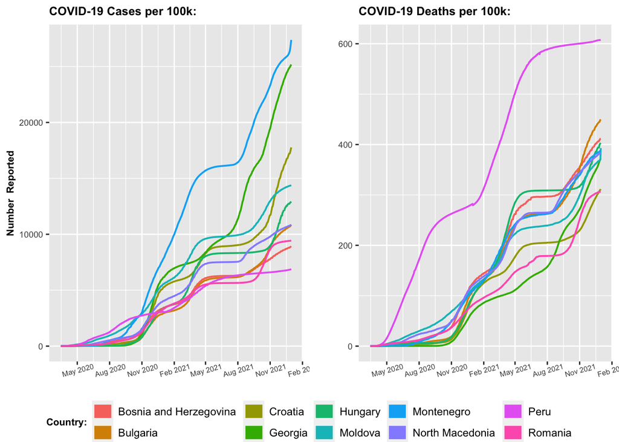

```r
## 1) Gather the COVID 19 data for only the top 10 countries
## 1b) based on our previous tidying
csse_10_tidy <- csse_global_tidy_1 %>% rename(
  country = "Country/Region"
)

## 1c) save the 10 countries in a vector
top_10_per100k_list <- top10_per100k$country
## 2d) convert that vector into a list class
top_10_per100k_list2 <- structure(list(top_10_per100k_list))
## 2e) use the list class 10 countries to filter our COVID data
csse_10_tidy2 <- csse_10_tidy[csse_10_tidy$country
                              %in% top_10_per100k_list2[[1]],]
## 3) set the date lower and upper bounds
csse_10_tidy2 <- csse_10_tidy2 %>%
  filter(date >= "2020-03-15") %>%
  filter(date <= "2021-12-31")

## 4) set up the population data set to work with our top 10 countries
global_pop_again <- global_population_estimates
## 4c) rename the variable because they suck
top_10_pop <- global_pop_again %>%
  rename(
    country = `Country Name`,
    pop_est_2020 = "2020 [YR2020]",
    pop_est_2021 = "2021 [YR2021]"
  )
## 4d) select only the variables we will use
top_10_pop <- top_10_pop %>%
  select(country, pop_est_2020, pop_est_2021)

## 4e) filter for the countries that are the top 10 using our previous list
top_10_pop_tidy <- top_10_pop[top_10_pop$country
                              %in% top_10_per100k_list2[[1]],]

## 5) Now, to work with the populations we need to change the class to numeric
## we'll use the same for loop method as before, once for the
## 5b) first for the 2020 pop.
top_10_pop_2020_as_num <-
    vector("double", length(top_10_pop_tidy$pop_est_2020))
  for(i in 1:length(top_10_pop_tidy$pop_est_2020)){
    top_10_pop_2020_as_num[i] <- as.numeric(top_10_pop_tidy$pop_est_2020[i])
  }
## 5c) the for the 2021 pop.
top_10_pop_2021_as_num <-
  vector("double", length(top_10_pop_tidy$pop_est_2021))
for(i in 1:length(top_10_pop_tidy$pop_est_2021)){
  top_10_pop_2021_as_num[i] <- as.numeric(top_10_pop_tidy$pop_est_2021[i])
}

## 6) add the two as columns into the data set for populations and
## select out the character versions

top_10_pop_tidy$num_2020 <- top_10_pop_2020_as_num
top_10_pop_tidy$num_2021 <- top_10_pop_2021_as_num

top_10_pop_tidy <- top_10_pop_tidy %>%
  select(country, num_2020, num_2021)

## 7) Combine the COVID tidy set with the pop. tidy set
## first check the sets
  ## top_10_pop_tidy
  ## csse_10_tidy2
  ## verify that new data set is correct
  ## ten_by_100k_inter

ten_by_100k_inter<- full_join(
  csse_10_tidy2,
  top_10_pop_tidy,
  by = "country"
)

ten_by_100k <- ten_by_100k_inter %>%
  select(
    country, date, cases, deaths, num_2020, num_2021
  )

## 8) use a for loop to calc. cases per 100k

cases_by100k <- vector("double", 6570)
for (i in 1:6570){
  if(substr(ten_by_100k$date[i], 1, 4) == "2020"){
    cases_by100k[i] <- (ten_by_100k$cases[i] / ten_by_100k$num_2020[i]*100000)
  }
  else{
    cases_by100k[i] <- (ten_by_100k$cases[i] / ten_by_100k$num_2021[i]*100000)
  }
}

## 9) use another for loop to calculate deaths per 100k
deaths_by100k <- vector("double", 6570)
for (i in 1:6570){
  if(substr(ten_by_100k$date[i], 1, 4) == "2020"){
    deaths_by100k[i] <- (ten_by_100k$deaths[i] / ten_by_100k$num_2020[i]*100000)
  }
  else{
    deaths_by100k[i] <- (ten_by_100k$deaths[i] / ten_by_100k$num_2021[i]*100000)
  }
}

## as_tibble(deaths_by100k)
## as_tibble(cases_by100k)
## check point

## 10) add the two columns
ten_by_100k$cases_by100k <- cases_by100k
ten_by_100k$deaths_by100k <- deaths_by100k

## NOW make it a visualization
plot_cases_by100k <- ten_by_100k %>%
  ggplot(
  aes(x = date,
      y = cases_by100k,
      color = country))+
    geom_line(size = .7)+
  labs(title = "COVID-19 Cases per 100k:",
       x = "",
       y = "Number  Reported",
       color = "Country:") +
  theme(title = element_text(face = "bold",
                             size = 8),
        axis.text.x = element_text(angle = 15,
                                   size = 6),
        axis.text.y = element_text(size = 7),
        axis.title.y = element_text(face = "bold"),
        axis.title.x = element_text(face = "bold"),
        legend.position = "none")+
  guides(color = guide_legend(override.aes = list(size = 2)))+
  scale_x_date(date_labels = "%b %Y",
               date_breaks = "3 months",
               limits = as.Date(c('2020-03-15','2021-12-31')))

plot_deaths_by100k <- ten_by_100k %>%
  ggplot(
  aes(x = date,
      y = deaths_by100k,
      color = country)) +
    geom_line(size = .7)+
  labs(title = "COVID-19 Deaths per 100k:",
       x = "",
       y = "",
       color = "Country:") +
  theme(title = element_text(face = "bold",
                             size = 8),
        axis.text.x = element_text(angle = 15, size = 6),
        axis.text.y = element_text(size = 7),
        axis.title.y = element_text(face = "bold"),
        axis.title.x = element_text(face = "bold"),
        legend.position = "none")+
  guides(color = guide_legend(override.aes = list(size = 2)),
         shape = guide_legend(override.aes = list(size = .2)))+
  scale_x_date(date_labels = "%b %Y",
               date_breaks = "3 months",
               limits = as.Date(c('2020-03-15','2021-12-31')))
## make the legend individually
legend <- get_legend(plot_deaths_by100k +
                       guides(color = guide_legend(nrow = 2))+
                       theme(legend.position = "bottom") +
                       guides(color = guide_legend(
                       override.aes = list(size = 5.1)
                     )))



plots_both <- plot_grid(
  plot_cases_by100k,
  plot_deaths_by100k,
  align = "vh",
  hjust = -1,
  nrow = 1
)

plot_grid(plots_both, legend, ncol = 1, rel_heights = c(1, .1))
```

– Communicate your methodology, results, and interpretation here – This plot like out previous data set shows that Peru has the highest COVID deaths per capita, but unlike the previous data set, highest cases per capita is Montenegro. This plot does a good job showing that the cases and deaths per capita varies, but the colors and lines do overlap causing some confusion potentially, even with jitter to prevent overlap there could be confusion.

##### Question 4

Finally, select four countries from one continent and create visualizations for the daily number of confirmed cases per 100,000 and the daily number of deaths per 100,000 people between March 15, 2020, and December 31, 2021.

```r
## 1) select four countries from 1 continent
## let's pick South America: Brazil, Colombia,

SA_4 <- csse_global_tidy_1 %>%
  rename(country = "Country/Region")

## 2) filter for the 4 countries

countries4 <- c("Colombia","Brazil",
                "Argentina","Chile")

countries4 <- structure(list(countries4))

SA_4 <- SA_4[SA_4$country
             %in% countries4[[1]],]

## 3) set the date boundaries
SA_4_tidy <- SA_4 %>%
  filter(date >= "2020-03-15") %>%
  filter(date <= "2021-12-31") %>%
  select(country, date, cases, deaths)

## 4) Now set up the population data set
SA_4_pop <- global_pop_again %>%
  rename(
    country = `Country Name`,
    pop_est_2020 = "2020 [YR2020]",
    pop_est_2021 = "2021 [YR2021]"
  )
## 4b) apply 4 countries
SA_4_pop2 <- SA_4_pop[SA_4_pop$country
                      %in% countries4[[1]],]
SA_4_pop2 <- SA_4_pop2 %>%
  select(country, pop_est_2020, pop_est_2021)

## 5) the pop est are not numbers they are character class, so change it!
SA_2020_as_num <- vector("double", length(SA_4_pop2$pop_est_2020))
  for(i in 1:length(SA_4_pop2$pop_est_2020)){
    SA_2020_as_num[i] <- as.numeric(SA_4_pop2$pop_est_2020[i])
  }
## 5c) the for the 2021 pop.
SA_2021_as_num <- vector("double", length(SA_4_pop2$pop_est_2021))
  for(i in 1:length(SA_4_pop2$pop_est_2021)){
    SA_2021_as_num[i] <- as.numeric(SA_4_pop2$pop_est_2021[i])
  }

## add these two back into the data set and get rid of the character columns
SA_4_pop2$pop_2020_num <- SA_2020_as_num
SA_4_pop2$pop_2021_num <- SA_2021_as_num
SA_4_pop2 <- SA_4_pop2 %>%
  select(country, pop_2020_num, pop_2021_num)

## 5b) combine the two data sets
SA_4countries_tidy <- full_join(
  SA_4_tidy,
  SA_4_pop2,
  by = "country"
)
#################### GOOD #######################

## 6) calculate the cases and deaths per 100k which will depend on the
## date to determine the right population estimate

cases_SA_100k <- vector("double", 2628)
for(i in 1:2628){
  if(substr(SA_4countries_tidy$date[i], 1, 4) == "2020"){
    cases_SA_100k[i] <- (SA_4countries_tidy$cases[i] /
                         SA_4countries_tidy$pop_2020_num[i]
                         * 100000)
  }
  else{
    cases_SA_100k[i] <- (SA_4countries_tidy$cases[i] /
                         SA_4countries_tidy$pop_2021_num[i]
                         *100000)
  }
}

## 6b) put this in as a column, verify the size matches
## as_tibble(cases_SA_100k)
## SA_4countries_tidy

SA_4countries_tidy$cases_by100k <- cases_SA_100k

## 6c) Repeat for deaths
deaths_SA_100k <- vector("double", 2628)
for(i in 1:2628){
  if(substr(SA_4countries_tidy$date[i], 1, 4) == "2020"){
    deaths_SA_100k[i] <- (SA_4countries_tidy$deaths[i] /
                         SA_4countries_tidy$pop_2020_num[i]
                         * 100000)
  }
  else{
    deaths_SA_100k[i] <- (SA_4countries_tidy$deaths[i] /
                         SA_4countries_tidy$pop_2021_num[i]
                         *100000)
  }
}

SA_4countries_tidy$deaths_by100k <- deaths_SA_100k

## 7) Print out our final data set which we will use to create a visualization
as_tibble(SA_4countries_tidy)
```

```
## # A tibble: 2,628 × 8
##    country   date       cases deaths pop_2020_num pop_2021_num cases_b…¹ death…²
##    <chr>     <date>     <dbl>  <dbl>        <dbl>        <dbl>     <dbl>   <dbl>
##  1 Argentina 2020-03-15    45      2     45376763     45784000    0.0992 0.00441
##  2 Argentina 2020-03-16    56      2     45376763     45784000    0.123  0.00441
##  3 Argentina 2020-03-17    68      2     45376763     45784000    0.150  0.00441
##  4 Argentina 2020-03-18    79      2     45376763     45784000    0.174  0.00441
##  5 Argentina 2020-03-19    97      3     45376763     45784000    0.214  0.00661
##  6 Argentina 2020-03-20   128      3     45376763     45784000    0.282  0.00661
##  7 Argentina 2020-03-21   158      4     45376763     45784000    0.348  0.00882
##  8 Argentina 2020-03-22   266      4     45376763     45784000    0.586  0.00882
##  9 Argentina 2020-03-23   301      4     45376763     45784000    0.663  0.00882
## 10 Argentina 2020-03-24   387      6     45376763     45784000    0.853  0.0132
## # … with 2,618 more rows, and abbreviated variable names ¹cases_by100k,
## #   ²deaths_by100k
```

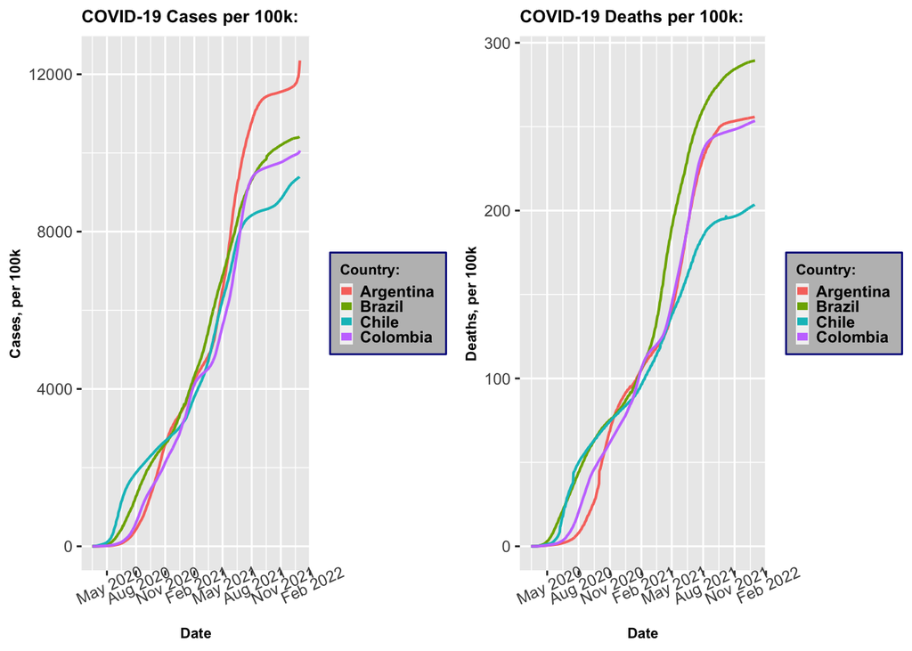

```r
## 8) Time to plot, make two plots then patch together
plot_SA_cases_by100k <- SA_4countries_tidy %>%
  ggplot(
  aes(x = date,
      y = cases_by100k,
      color = country))+
    geom_line(size = .7,
              position = position_jitter(w = 0.05, h =0))+
  labs(title = "COVID-19 Cases per 100k:",
       x = "Date",
       y = "Cases, per 100k",
       color = "Country:") +
  theme(title = element_text(face = "bold",
                             size = 8),
        axis.text.x = element_text(angle = 25),
        axis.title.y = element_text(face = "bold"),
        axis.title.x = element_text(face = "bold"),
        legend.background = element_rect(fill = "grey",
                                         size = .5,
                                         linetype = "solid",
                                         color = "darkblue"),
        legend.text = element_text(color = "black", face = "bold"),
        legend.key.size = unit(.5, "line"))+
  guides(color = guide_legend(override.aes = list(size = 2)))+
  scale_x_date(date_labels = "%b %Y",
               date_breaks = "3 months",
               limits = as.Date(c('2020-03-15','2021-12-31')))


plot_SA_deaths_by100k <- SA_4countries_tidy %>%
  ggplot(
  aes(x = date,
      y = deaths_by100k,
      color = country))+
    geom_line(size = .7,
              position = position_jitter(w = 0.05, h = 0))+
  labs(title = "COVID-19 Deaths per 100k:",
       x = "Date",
       y = "Deaths, per 100k",
       color = "Country:") +
  theme(title = element_text(face = "bold",
                             size = 8),
        axis.text.x = element_text(angle = 25),
        axis.title.y = element_text(face = "bold"),
        axis.title.x = element_text(face = "bold"),
        legend.background = element_rect(fill = "grey",
                                         size = .5,
                                         linetype = "solid",
                                         color = "darkblue"),
        legend.text = element_text(color = "black", face = "bold"),
        legend.key.size = unit(.5, "line"))+
  guides(color = guide_legend(override.aes = list(size = 2)))+
  scale_x_date(date_labels = "%b %Y",
               date_breaks = "3 months",
               limits = as.Date(c('2020-03-15','2021-12-31')))

plot_grid(plot_SA_cases_by100k, plot_SA_deaths_by100k)
```

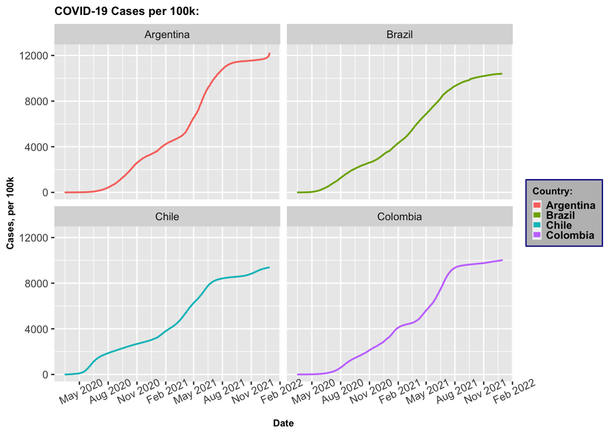

```r
plot_SA_cases_by100k + facet_wrap(~country)
```

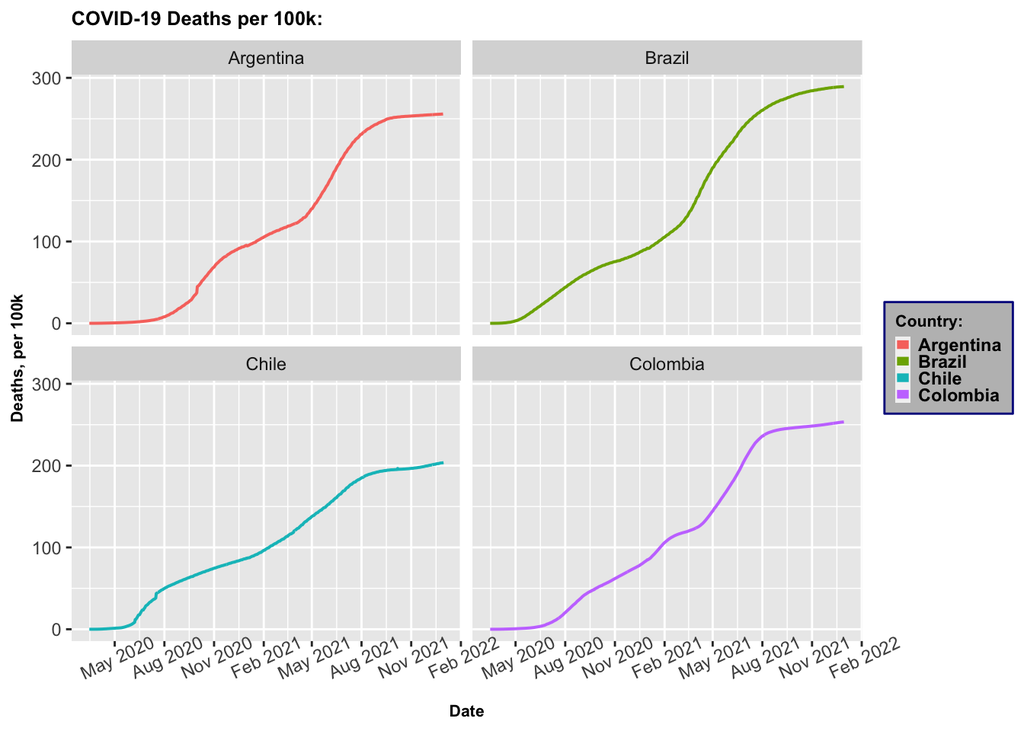

```r
plot_SA_deaths_by100k + facet_wrap(~country)
```

– Communicate your methodology, results, and interpretation here – For the most part, we used the same methodology as before. However, when plotting, we tried facet_wrap in order to avoid the overlapping, although it is not as easy to tell exactly how close the rates are related to one another for the 4 countries they are pretty similar overall for both cases and deaths. The scales make it very clear that there were much more cases per 100,000 people for all 4 countries. Additionally, the 4 countries show that their cases and deaths rate follows a similar slope and shape, therefore when cases go down, deaths go down which tells us our data is likely correct.